I wanted to simulate what we talked about to make sure I was thinking about it right, turns out I got two things wrong so I wanted to correct those here.

```r
#install.packages('lme4')
#install.packages('car)
#install.packages('ggplot2)
#install.packages('tidyverse')

library(lme4)
library(car)
library(ggplot2)
library(ggeffects)
library(tidyverse)
```

# Simulated Data

Simulate data that looks like survival data Here I had an AI do it because the data structure is complicated, ignore this part

```r
set.seed(1)

# --- Define structure ---
n_mice <- 6
n_dendrites_per_mouse <- 4
n_spines_per_dendrite <- 10
days <- 1:8

# --- Mouse-level info ---
mouse_ids <- paste0("mouse_", sample(1000:9999, n_mice))
genotypes <- rep_len(c("wt", "exp"), n_mice)  # alternating, or randomize
mouse_df <- tibble(
  mouse_id = mouse_ids,
  genotype = genotypes
)

# --- Dendrite-level info ---
dendrite_df <- tibble(
  mouse_id = rep(mouse_ids, each = n_dendrites_per_mouse),
  dendrite_id = paste0("dend_", sample(10000:99999, n_mice * n_dendrites_per_mouse))
)

# --- Spine-level skeleton ---
spine_df <- tibble(
  dendrite_id = rep(dendrite_df$dendrite_id, each = n_spines_per_dendrite),
  spine_id = paste0("spine_", sample(100000:999999, n_mice * n_dendrites_per_mouse * n_spines_per_dendrite))
)

# --- Expand to daily observations ---
df <- spine_df %>%
  tidyr::crossing(day = days) %>%
  left_join(dendrite_df, by = "dendrite_id") %>%
  left_join(mouse_df, by = "mouse_id")

# --- Add cut ---
df <- df %>%
  mutate(cut = day >= 5)

# --- Simulate spine presence (survival-style, but with random start) ---
# For each spine: sample a birth day (or never born = Inf), and a death day
# Spine is present (1) between birth and death day, inclusive

spine_survival <- spine_df %>%
  distinct(spine_id) %>%
  mutate(
    birth_day = sample(1:8, n(), replace = TRUE),   # day spine first appears
    # death day is >= birth day; some spines survive the whole window
    lifespan  = sample(1:8, n(), replace = TRUE),   # how many days it lives
    death_day = pmin(birth_day + lifespan - 1, 8)
  )

df <- df %>%
  left_join(spine_survival, by = "spine_id") %>%
  mutate(
    spine = as.integer(day >= birth_day & day <= death_day)
  ) %>%
  select(-birth_day, -lifespan, -death_day)

# --- Add area (only meaningful when spine == 1, but simulate for all) ---
df <- df %>%
  mutate(
    area = rnorm(n(), mean = 1.5, sd = 0.4),
    day  = factor(day)
  )

# --- Final column order ---
df <- df %>%
  select(mouse_id, genotype, dendrite_id, spine_id, day, cut, spine, area)

days <- 1:8
cut_day <- 5

# initialize each spine as alive on day 1 with some probability
spine_states <- spine_df %>%
  mutate(alive = rbinom(n(), 1, 0.5))  # baseline prevalence

all_days <- list()

for (d in days) {

  # define rates
  if (d < cut_day) {
    p_birth <- 0.05
    p_death <- 0.05
  } else {
    p_birth <- 0.05
    p_death <- 0.25   # increased death after cut
  }

  # deaths
  died <- rbinom(nrow(spine_states), 1, p_death)
  spine_states$alive <- ifelse(spine_states$alive == 1 & died == 1, 0, spine_states$alive)

  # births (only for currently dead spines)
  born <- rbinom(nrow(spine_states), 1, p_birth)
  spine_states$alive <- ifelse(spine_states$alive == 0 & born == 1, 1, spine_states$alive)

  all_days[[d]] <- spine_states %>%
    mutate(day = d, spine = alive)
}

df2 <- bind_rows(all_days) %>%
  left_join(dendrite_df, by = "dendrite_id") %>%
  left_join(mouse_df, by = "mouse_id") %>%
  mutate(day = factor(day),
         cut = day %in% 5:8)
df2$area =df$area
```

Ok we have some fake data

```r
glimpse(df2)
```

```
## Rows: 1,920
## Columns: 9
## $ dendrite_id <chr> "dend_42617", "dend_42617", "dend_42617", "dend_42617", "d…
## $ spine_id    <chr> "spine_913307", "spine_467324", "spine_844043", "spine_900…
## $ alive       <dbl> 1, 0, 1, 1, 1, 0, 1, 1, 1, 0, 1, 1, 0, 0, 0, 0, 0, 1, 1, 1…
## $ day         <fct> 1, 1, 1, 1, 1, 1, 1, 1, 1, 1, 1, 1, 1, 1, 1, 1, 1, 1, 1, 1…
## $ spine       <dbl> 1, 0, 1, 1, 1, 0, 1, 1, 1, 0, 1, 1, 0, 0, 0, 0, 0, 1, 1, 1…
## $ mouse_id    <chr> "mouse_2016", "mouse_2016", "mouse_2016", "mouse_2016", "m…
## $ genotype    <chr> "wt", "wt", "wt", "wt", "wt", "wt", "wt", "wt", "wt", "wt"…
## $ cut         <lgl> FALSE, FALSE, FALSE, FALSE, FALSE, FALSE, FALSE, FALSE, FA…
## $ area        <dbl> 1.9386561, 1.4009961, 1.4360393, 1.2496887, 1.8601739, 1.1…
```

# Logistic Regression

Here, we specify a logistic regression using glmer with the parameters we discussed

I want to point out something I realized after our discussion, if we consider day as a categorical variable rather than continuous, then day as a factor perfectly covaries with cut, so cut must be removed from the model, **two variables cannot perfectly covary**. We can still analyze the difference before vs after the cut by just looking at the probability of survival before and after, and we could probably recover the p-value of the cut in some way, though I’d have to think more about it.

Because the spine is the unit of repeated measurement, **we should actually include a random effect of spine nested within dendrite (1|dendrite_id/spine_id)**. If we wanted to be super precise we would do (1|mouse/dendrite/spine), but that may be too conservative statistically.

```r
model = glmer(spine ~genotype*day +(1|dendrite_id/spine_id), data = df2,
              family = 'binomial',
             control = glmerControl(optimizer = "bobyqa") #I include this optimizer because the model was not able to converge with my fake data, hopefully it does with the real data
             )
```

```
## boundary (singular) fit: see help('isSingular')
```

```r
summary(model)
```

```
## Generalized linear mixed model fit by maximum likelihood (Laplace
##   Approximation) [glmerMod]
##  Family: binomial  ( logit )
## Formula: spine ~ genotype * day + (1 | dendrite_id/spine_id)
##    Data: df2
## Control: glmerControl(optimizer = "bobyqa")
##
##       AIC       BIC    logLik -2*log(L)  df.resid
##    1764.0    1864.1    -864.0    1728.0      1902
##
## Scaled residuals:
##     Min      1Q  Median      3Q     Max
## -3.8901 -0.2721 -0.0948  0.3705  6.4339
##
## Random effects:
##  Groups               Name        Variance Std.Dev.
##  spine_id:dendrite_id (Intercept) 11.17    3.342
##  dendrite_id          (Intercept)  0.00    0.000
## Number of obs: 1920, groups:  spine_id:dendrite_id, 240; dendrite_id, 24
##
## Fixed effects:
##                 Estimate Std. Error z value Pr(>|z|)
## (Intercept)       0.1675     0.4230   0.396 0.692139
## genotypewt       -0.8847     0.5943  -1.489 0.136598
## day2              0.2473     0.3982   0.621 0.534498
## day3              0.5007     0.4021   1.245 0.213056
## day4              0.7623     0.4069   1.873 0.061010 .
## day5             -0.9583     0.3920  -2.445 0.014497 *
## day6             -1.4367     0.3964  -3.625 0.000289 ***
## day7             -1.9310     0.4051  -4.767 1.87e-06 ***
## day8             -2.1901     0.4114  -5.324 1.01e-07 ***
## genotypewt:day2  -0.2473     0.5521  -0.448 0.654181
## genotypewt:day3  -0.2691     0.5564  -0.484 0.628591
## genotypewt:day4  -0.2171     0.5624  -0.386 0.699523
## genotypewt:day5   0.8815     0.5473   1.611 0.107265
## genotypewt:day6   0.1967     0.5541   0.355 0.722669
## genotypewt:day7   0.5284     0.5625   0.939 0.347540
## genotypewt:day8   0.4502     0.5726   0.786 0.431749
## ---
## Signif. codes:  0 '***' 0.001 '**' 0.01 '*' 0.05 '.' 0.1 ' ' 1
```

```
##
## Correlation matrix not shown by default, as p = 16 > 12.
## Use print(x, correlation=TRUE)  or
##     vcov(x)        if you need it
```

```
## optimizer (bobyqa) convergence code: 0 (OK)
## boundary (singular) fit: see help('isSingular')
```

# Type 3 tests

```r
car::Anova(model, 3)
```

```
## Analysis of Deviance Table (Type III Wald chisquare tests)
##
## Response: spine
##                Chisq Df Pr(>Chisq)
## (Intercept)   0.1568  1     0.6921
## genotype      2.2159  1     0.1366
## day          92.5704  7     <2e-16 ***
## genotype:day  7.6083  7     0.3684
## ---
## Signif. codes:  0 '***' 0.001 '**' 0.01 '*' 0.05 '.' 0.1 ' ' 1
```

There should be a significant effect of day because thats the way the data was made.

# Plot marginal estimates

```r
newdata = ggpredict(model, 'day')%>%
  as.data.frame(terms_to_colnames= T)
```

```
## You are calculating adjusted predictions on the population-level (i.e.
##   `type = "fixed"`) for a *generalized* linear mixed model.
##   This may produce biased estimates due to Jensen's inequality. Consider
##   setting `bias_correction = TRUE` to correct for this bias.
##   See also the documentation of the `bias_correction` argument.
```

```r
newdata
```

```
##   day predicted  std.error  conf.low conf.high group
## 1   1 0.5417703 0.10500138 0.4904193 0.5922490     1
## 2   2 0.6022377 0.10180095 0.5536110 0.6489265     1
## 3   3 0.6610999 0.09572536 0.6178852 0.7017862     1
## 4   4 0.7170336 0.08718872 0.6811166 0.7503878     1
## 5   5 0.3119926 0.09001826 0.2754284 0.3510590     1
## 6   6 0.2193809 0.07210891 0.1961381 0.2445402     1
## 7   7 0.1463472 0.05316530 0.1338029 0.1598505     1
## 8   8 0.1168495 0.04427715 0.1081875 0.1261070     1
```

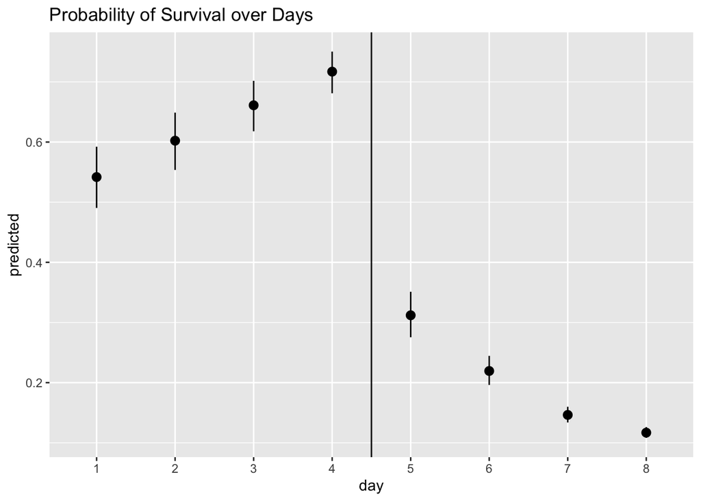

```r
ggplot(newdata, aes(x =day, y = predicted ))+
  geom_pointrange(aes(x = day, y = predicted, ymin = conf.low, ymax = conf.high))+
  labs(title = 'Probability of Survival over Days')+
  geom_vline(xintercept = 4.5)
```

I appreciate that survival probability should not increase over days, I think this is due to how death and birth were simulated and not due to some aspect of the model.

```r
newdata2 = ggpredict(model, 'genotype')%>%
  as.data.frame(terms_to_colnames= T)
newdata2
```

```
##   genotype predicted std.error  conf.low conf.high group
## 1      exp 0.5417703 0.1050014 0.4904193 0.5922490     1
## 2       wt 0.3279966 0.0920361 0.2895341 0.3689153     1
```

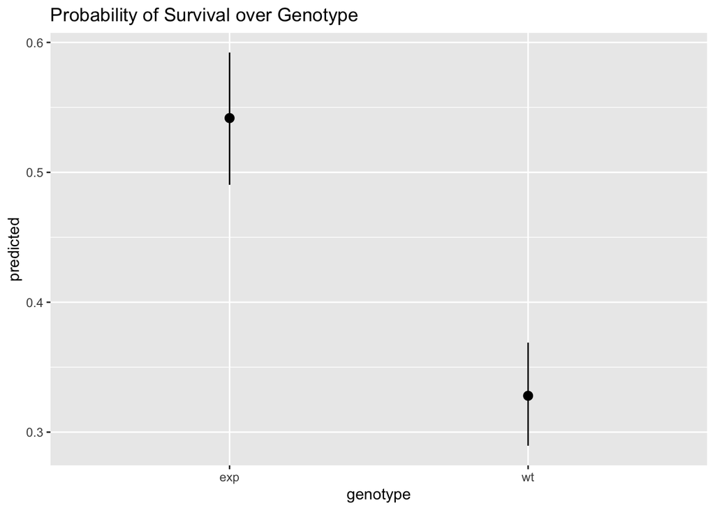

```r
ggplot(newdata2, aes(x =genotype, y = predicted ))+
  geom_pointrange(aes(x = genotype, y = predicted, ymin = conf.low, ymax = conf.high))+
  labs(title = 'Probability of Survival over Genotype')
```

# Plot marginal estimates with specific perturbations

What if we just wanted to see how the survival would look if all the genotypes were WT

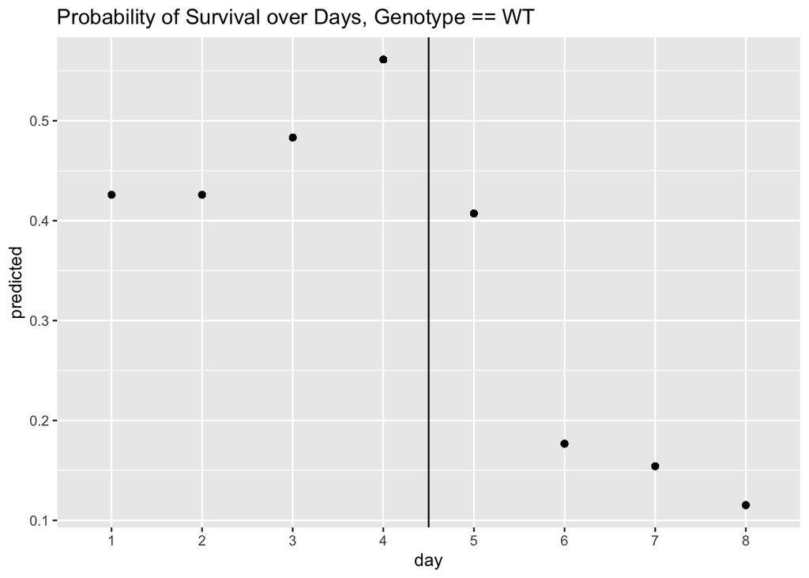

```r
newdata3 = df2
newdata3$genotype='wt'
newdata3$dendrite_id = df$dendrite_id[1]
newdata3$spine_id = df$spine_id[1] # random effects add a lot of noise so we keep them stable

prediction = predict(model, newdata3, type = 'response')
newdata3$predicted = prediction

ggplot(newdata3, aes(x =day, y = predicted))+
  geom_point()+
  labs(title = 'Probability of Survival over Days, Genotype == WT')+
  geom_vline(xintercept = 4.5)
```

Or experimental

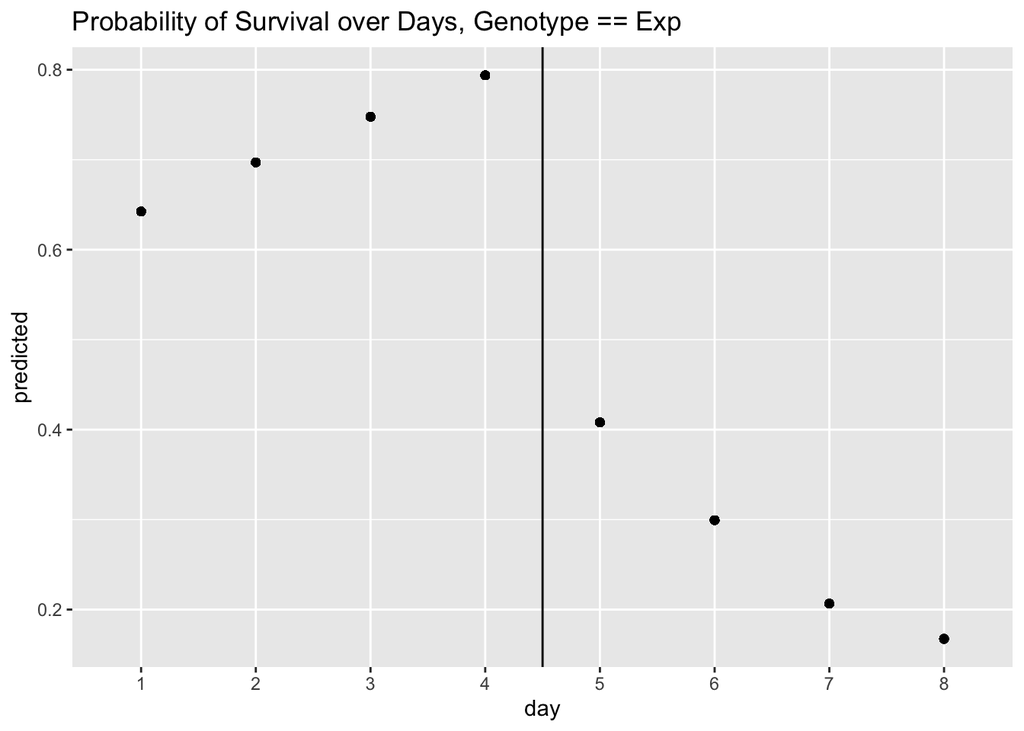

```r
newdata4 = df2
newdata4$genotype='exp'
newdata4$dendrite_id = df$dendrite_id[1]
newdata4$spine_id = df$spine_id[1] # random effects add a lot of noise so we keep them stable

prediction = predict(model, newdata4, type = 'response')
newdata4$predicted = prediction

ggplot(newdata4, aes(x =day, y = predicted))+
  geom_point()+
  labs(title = 'Probability of Survival over Days, Genotype == Exp')+
  geom_vline(xintercept = 4.5)
```